# Estymacja wariancji przez bootstrap

```r
library(boot)        # klasyczny bootstrap
library(nonprobsvy)  # >= 0.2.3 -- wbudowany bootstrap dla IPW/MI/DR
library(survey)
set.seed(2026)
```

# 1 Wprowadzenie

**Bootstrap** (Efron 1979) to nieparametryczna metoda szacowania wariancji estymatora poprzez **resampling** z obserwowanej próby. Idea:

> Skoro próba jest reprezentatywna dla populacji, losowanie ze zwracaniem z próby naśladuje powtórne losowanie z populacji.

Procedura ogólna dla statystyki $\hat\theta = T(x_1, \ldots, x_n)$:

1. Dla $b = 1, \ldots, B$: wylosuj **ze zwracaniem** $n$ obserwacji z $\{x_1, \ldots, x_n\}$, otrzymując $\{x_1^{*(b)}, \ldots, x_n^{*(b)}\}$.
2. Oblicz $\hat\theta^{*(b)} = T(x_1^{*(b)}, \ldots, x_n^{*(b)})$.
3. Estymuj wariancję:

$$\hat V_{\text{boot}}(\hat\theta) = \frac{1}{B-1}\sum_{b=1}^{B}\bigl(\hat\theta^{*(b)} - \bar{\hat\theta}^*\bigr)^{\!2}.$$

Plan notatnika:

1. Bootstrap dla średniej – prosty przykład.
2. Bootstrap dla współczynników regresji – przy heteroskedastyczności.
3. Bootstrap w próbach nielosowych (sztuczny przykład) – analityczne vs bootstrap.
4. Realne dane `admin`/`jvs` – bootstrap dla IPW, MI, DR.

# 2 Część A: Bootstrap dla średniej

## 2.1 Generowanie danych

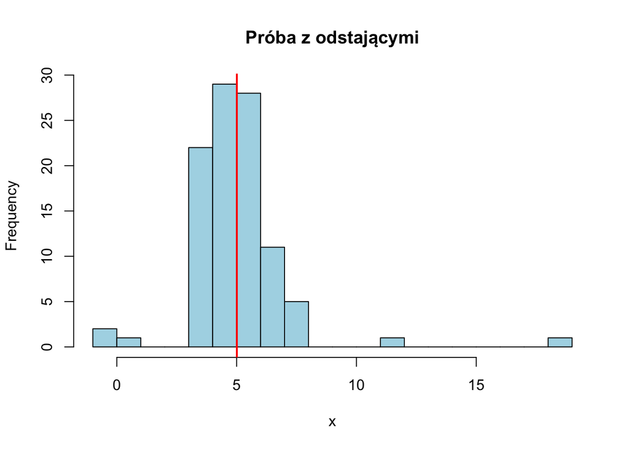

```r
n <- 100
contam <- rbinom(n, 1, 0.1)               # 10% odstających
x <- rnorm(n, mean = 5, sd = ifelse(contam, 5, 1))
hist(x, breaks = 20, main = "Próba z odstającymi", col = "lightblue")
abline(v = mean(x), col = "red", lwd = 2)
```

Naszą statystyką jest średnia $\bar x$.

```r
xbar  <- mean(x)
se_cl <- sd(x)/sqrt(n)
cat("Średnia:", round(xbar, 3), "\n")
```

```
Średnia: 5.01
```

```r
cat("Klasyczne SE:", round(se_cl, 3), "\n")
```

```
Klasyczne SE: 0.204
```

```r
cat("Klasyczne 95% CI: [", round(xbar - 1.96*se_cl, 3),
    ",", round(xbar + 1.96*se_cl, 3), "]\n")
```

```
Klasyczne 95% CI: [ 4.611 , 5.409 ]
```

## 2.2 Bootstrap z pakietu `boot`

Funkcja `boot::boot()` wymaga funkcji `statistic(data, indices)` zwracającej wartość statystyki dla próbki indeksów `indices`.

```r
mean_stat <- function(data, idx) mean(data[idx])

B <- 1000
boot_res <- boot(data = x, statistic = mean_stat, R = B)
boot_res
```

```
ORDINARY NONPARAMETRIC BOOTSTRAP


Call:
boot(data = x, statistic = mean_stat, R = B)


Bootstrap Statistics :
    original       bias    std. error
t1* 5.009925 -0.001502696   0.2064389
```

Wariancja bootstrap to wariancja replikacji `boot_res$t`:

```r
se_boot <- sd(boot_res$t)
cat("Bootstrap SE:", round(se_boot, 3), "\n")
```

```
Bootstrap SE: 0.206
```

```r
ci_perc <- quantile(boot_res$t, c(0.025, 0.975))
cat("Bootstrap 95% percentile CI: [",
    round(ci_perc[1], 3), ",", round(ci_perc[2], 3), "]\n")
```

```
Bootstrap 95% percentile CI: [ 4.617 , 5.429 ]
```

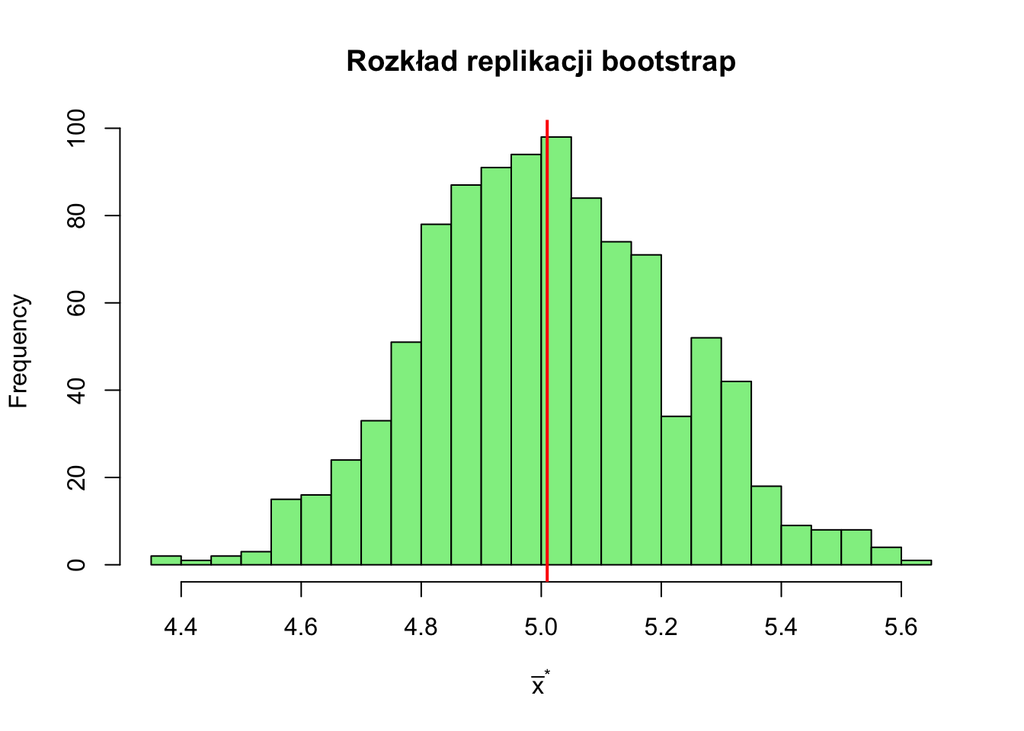

```r
# rozkład replikacji
hist(boot_res$t, breaks = 30, main = "Rozkład replikacji bootstrap",
     xlab = expression(bar(x)^"*"), col = "lightgreen")
abline(v = xbar, col = "red", lwd = 2)
```

Dla średniej z dużej próby klasyczne SE i bootstrap SE są zwykle bardzo zbliżone.

# 3 Część B: Bootstrap dla regresji (heteroskedastyczność)

## 3.1 Generowanie danych z heteroskedastycznym błędem

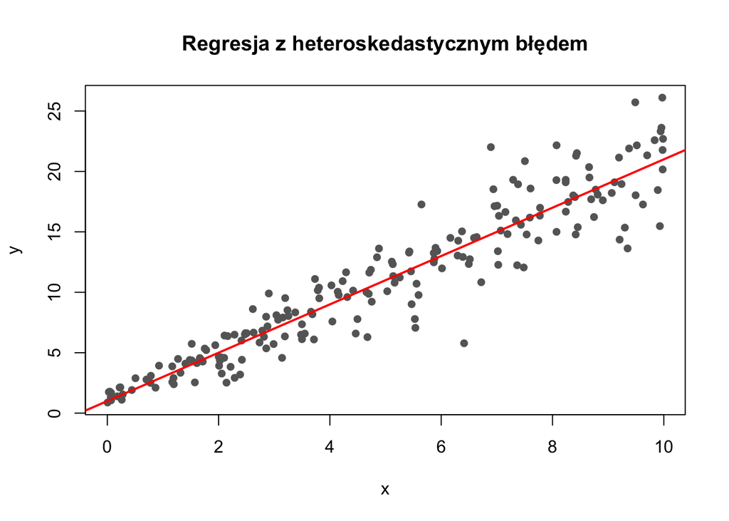

```r
n <- 200
x <- runif(n, 0, 10)
# wariancja błędu rośnie z x -- heteroskedastyczność
sigma_i <- 0.5 + 0.3 * x
y <- 1 + 2*x + rnorm(n, sd = sigma_i)

plot(x, y, pch = 16, col = "gray40",
     main = "Regresja z heteroskedastycznym błędem")
abline(coef = c(1, 2), col = "red", lwd = 2)
```

## 3.2 Klasyczne SE z `lm`

```r
fit <- lm(y ~ x)
summary(fit)$coefficients
```

```
             Estimate Std. Error   t value     Pr(>|t|)
(Intercept) 0.9866306 0.28747909  3.432008 7.293516e-04
x           2.0083315 0.05002768 40.144403 4.443993e-97
```

## 3.3 Paired bootstrap

```r
beta_stat <- function(data, idx) {
  m <- lm(y ~ x, data = data[idx, ])
  coef(m)
}

dat <- data.frame(x = x, y = y)
boot_lm <- boot(dat, beta_stat, R = 1000)
boot_lm
```

```
ORDINARY NONPARAMETRIC BOOTSTRAP


Call:
boot(data = dat, statistic = beta_stat, R = 1000)


Bootstrap Statistics :
     original       bias    std. error
t1* 0.9866306  0.003282099  0.19494316
t2* 2.0083315 -0.000931221  0.05085697
```

```r
se_boot_lm <- apply(boot_lm$t, 2, sd)
data.frame(
  parametr = c("intercept", "x"),
  est        = coef(fit),
  se_klasyczne = sqrt(diag(vcov(fit))),
  se_bootstrap = se_boot_lm
)
```

```
             parametr       est se_klasyczne se_bootstrap
(Intercept) intercept 0.9866306   0.28747909   0.19494316
x                   x 2.0083315   0.05002768   0.05085697
```

# 4 Część C: Bootstrap w próbach nielosowych (sztuczny przykład)

## 4.1 Generowanie populacji i prób

Używamy tego samego DGP co w notatniku `09-varsel` (Część B).

```r
N <- 5000
p <- 5
X_pop <- matrix(rnorm(N*p), N, p)
y_pop <- 1 + 2*X_pop[,1] - 1.5*X_pop[,2] + rnorm(N)
mu_true <- mean(y_pop)

# selekcja zależy od x3, x4
eta  <- -2 + X_pop[,3] - 0.5*X_pop[,4]
pi_A <- 1/(1 + exp(-eta))
R_A  <- rbinom(N, 1, pi_A)

# próba probabilistyczna S_B: SRS o n_B = 300
n_B <- 300
idx_B <- sample.int(N, n_B)

S_A <- data.frame(X_pop[R_A == 1, ], y = y_pop[R_A == 1])
colnames(S_A) <- c(paste0("x", 1:p), "y")
S_B <- data.frame(X_pop[idx_B, ], d = N/n_B)
colnames(S_B) <- c(paste0("x", 1:p), "d")

sb_svy <- svydesign(ids = ~1, weights = ~d, data = S_B)

cat("mu_y =", round(mu_true, 3), "; |S_A| =", sum(R_A), "; |S_B| =", n_B, "\n")
```

```
mu_y = 1.047 ; |S_A| = 824 ; |S_B| = 300
```

## 4.2 IPW z wariancją analityczną i bootstrap

W pakiecie `nonprobsvy` wybieramy `var_method = "analytic"` lub `"bootstrap"` w `control_inf()`.

```r
ipw_analyt <- nonprob(data      = S_A,
                      selection = ~ x1 + x2 + x3 + x4 + x5,
                      target    = ~ y,
                      svydesign = sb_svy,
                      control_inference = control_inf(var_method = "analytic"))
ipw_analyt
```

```
A nonprob object
 - estimator type: inverse probability weighting
 - method: logit (mle)
 - IPW point estimator: Hajek (denominator: estimated IPW weights = 4895.2426)
 - auxiliary variables source: survey
 - vars selection: false
 - variance estimator: analytic
 - population size fixed: false
 - naive (uncorrected) estimator: 1.2064
 - selected estimator: 0.5690 (se=0.3518, ci=(-0.1205, 1.2584))
```

```r
ipw_boot <- nonprob(data      = S_A,
                    selection = ~ x1 + x2 + x3 + x4 + x5,
                    target    = ~ y,
                    svydesign = sb_svy,
                    control_inference = control_inf(var_method = "bootstrap",
                                                    num_boot = 200))
ipw_boot
```

```
A nonprob object
 - estimator type: inverse probability weighting
 - method: logit (mle)
 - IPW point estimator: Hajek (denominator: estimated IPW weights = 4895.2426)
 - auxiliary variables source: survey
 - vars selection: false
 - variance estimator: bootstrap (with 200 samples, multicore: false)
 - population size fixed: false
 - naive (uncorrected) estimator: 1.2064
 - selected estimator: 0.5690 (se=0.3375, ci=(-0.0925, 1.2305))
```

## 4.3 Porównanie

```r
rbind(
  "IPW analityczne" = extract(ipw_analyt),
  "IPW bootstrap"   = extract(ipw_boot)
)
```

```
                target     mean        SE lower_bound upper_bound
IPW analityczne      y 0.568979 0.3517673 -0.12047230    1.258430
IPW bootstrap        y 0.568979 0.3375037 -0.09251599    1.230474
```

```r
cat("\nPrawdziwa wartość mu_y =", round(mu_true, 3), "\n")
```

```
Prawdziwa wartość mu_y = 1.047
```

Dla poprawnie wyspecyfikowanego modelu PS oba podejścia powinny dawać zbliżone SE. Bootstrap jest **wolniejszy** (tu 200 replikacji × pełne dopasowanie modelu).

## 4.4 Rozkład replikacji bootstrap

Argument `keep_boot = TRUE` (domyślnie) zachowuje wektor estymatorów z każdej replikacji w `ipw_boot$boot_sample`.

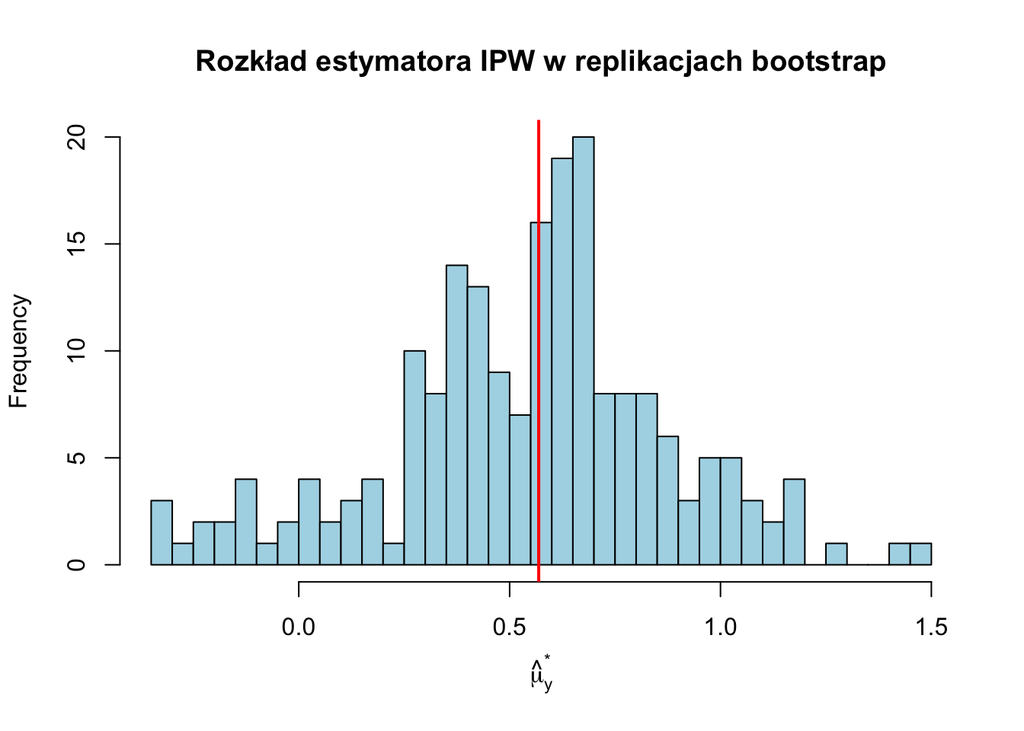

```r
if (!is.null(ipw_boot$boot_sample)) {
  hist(ipw_boot$boot_sample, breaks = 30,
       main = "Rozkład estymatora IPW w replikacjach bootstrap",
       xlab = expression(hat(mu)[y]^"*"), col = "lightblue")
  abline(v = ipw_boot$output$mean, col = "red", lwd = 2)
}
```

# 5 Część D: Realne dane `admin` i `jvs`

## 5.1 Wczytanie

```r
data(admin)
data(jvs)

jvs_svy <- svydesign(ids = ~ 1,
                     weights = ~ weight,
                     strata = ~ size + nace + region,
                     data = jvs)
```

## 5.2 IPW – analityczne vs bootstrap

```r
ipw_real_a <- nonprob(data      = admin,
                      selection = ~ size + nace + region + private,
                      target    = ~ single_shift,
                      svydesign = jvs_svy,
                      method_selection = "logit",
                      control_inference = control_inf(var_method = "analytic"))
```

```r
ipw_real_b <- nonprob(data      = admin,
                      selection = ~ size + nace + region + private,
                      target    = ~ single_shift,
                      svydesign = jvs_svy,
                      method_selection = "logit",
                      control_inference = control_inf(var_method = "bootstrap",
                                                      num_boot = 200))
```

## 5.3 MI z bootstrapem

```r
mi_real_b <- nonprob(data      = admin,
                     outcome   = single_shift ~ size + nace + region + private,
                     svydesign = jvs_svy,
                     method_outcome = "glm",
                     family_outcome = "binomial",
                     control_inference = control_inf(var_method = "bootstrap",
                                                     num_boot = 200))
```

## 5.4 DR z bootstrapem

```r
dr_real_b <- nonprob(data      = admin,
                     selection = ~ size + nace + region + private,
                     outcome   = single_shift ~ size + nace + region + private,
                     svydesign = jvs_svy,
                     method_outcome = "glm",
                     family_outcome = "binomial",
                     control_inference = control_inf(var_method = "bootstrap",
                                                     num_boot = 200))
```

## 5.5 Porównanie

```r
rbind(
  "IPW analityczne" = extract(ipw_real_a),
  "IPW bootstrap"   = extract(ipw_real_b),
  "MI bootstrap"    = extract(mi_real_b),
  "DR bootstrap"    = extract(dr_real_b)
)
```

```
                      target      mean          SE lower_bound upper_bound
IPW analityczne single_shift 0.7083229 0.009436904   0.6898269   0.7268189
IPW bootstrap   single_shift 0.7083229 0.010929242   0.6869020   0.7297438
MI bootstrap    single_shift 0.7032089 0.008669247   0.6862175   0.7202003
DR bootstrap    single_shift 0.7034695 0.010967689   0.6819732   0.7249657
```

# 6 Zadania do samodzielnego rozwiązania

## 6.1 Zadanie 1: bootstrap a rozmiar próby

Wykorzystując DGP z **Części A** (mieszanka z 10% odstających):

1. Powtórz analizę dla $n \in \{30, 100, 500\}$. Jak zmienia się stosunek bootstrap SE / klasyczne SE?
2. Porównaj kształty rozkładu replikacji (histogram) dla różnych $n$. Czy rozkład staje się bliższy normalnemu?
3. Zmień frakcję odstających z 10% na 30%. Jak zmienia się różnica między klasycznym a bootstrap SE?

## 6.2 Zadanie 2: bootstrap dla mediany

Mediana nie ma wzorów analitycznych SE w prostej formie. Bootstrap jest naturalnym wyborem.

1. Wykorzystując dane z Części A, oblicz bootstrap SE dla mediany.
2. Porównaj z bootstrap SE dla średniej. Która statystyka ma mniejszą wariancję dla tych danych z odstającymi?
3. Powtórz dla danych **bez** odstających (czyste $N(5, 1)$, $n = 100$). Czy wniosek się zmienia?

## 6.3 Zadanie 3: liczba replikacji $B$

Wykorzystując IPW na realnych danych (Część D):

1. Powtórz oszacowanie z `num_boot = 50, 100, 500, 1000`. Jak stabilizuje się bootstrap SE?
2. Wybierz minimalną wartość $B$, przy której SE nie zmienia się więcej niż o 5% pomiędzy dwoma kolejnymi uruchomieniami z różnymi `set.seed()`.

## 6.4 Zadanie 4: bootstrap przy złym modelu PS

Wykorzystując DGP z **Części C** (sztuczny przykład):

1. Dopasuj IPW z modelem PS zawierającym **tylko** zmienne nieistotne (np. `~ x1 + x2 + x5`) – pomijając $x_3, x_4$ sterujące selekcją.
2. Porównaj analityczne i bootstrap SE. Czy bootstrap “łapie” obciążenie wynikające ze złej specyfikacji modelu?
3. Sprawdź przedział ufności – czy zawiera prawdziwe $\mu_y \approx 1$?